# ISLR Chapter 6

Abhirup Sen

10/05/2021

```r
library(tidyverse)
library(ISLR)
library(leaps) # regsubsets() - best subset selection
library(glmnet) # ridge & lasso
library(caret)
library(pls) # PCR
library(MASS) # Boston data
# MASS/dplyr conflict:
select <- dplyr::select

# caret::train with RSS & MSE added:
custom_regression_metrics <- function (data, lev = NULL, model = NULL) {
  c(RMSE = sqrt(mean((data$obs-data$pred)^2)),
    Rsquared = summary(lm(pred ~ obs, data))$r.squared,
    MAE = mean(abs(data$obs-data$pred)),
    MSE = mean((data$obs-data$pred)^2),
    RSS = sum((data$obs-data$pred)^2))
}

theme_set(theme_light())
```

#Generated Data (Best Subset, Forwards, Backwards & Lasso Selection)

**(a) Generate X & ϵ** Q: Use the rnorm() function to generate a predictor X of length n = 100, as well as a noise vector ϵ of length n = 100.

```r
set.seed(123)
X <- rnorm(100)
error <- rnorm(100)
```

**(b) Generate Y** Q: Generate a response vector Y of length n = 100 according to the model Y=β0+β1X+β2X2+β3X3+ϵ where β0, β1, β2 & β3 are constants of your choice.

```r
Y <- 10 - 5*X + 6*X^2 + 3*X^3 + error
```

**(c) Best Subset Selection** Q: Use the regsubsets() function to perform best subset selection in order to choose the best model containing the predictors X,X2,…,X10. What is the best model obtained according to Cp, BIC, and adjusted R2? Show some plots to provide evidence for your answer, and report the coefficients of the best model obtained. Note you will need to use the data.frame() function to create a single data set containing both X and Y.

```r
X_matrix <- poly(X, 10, raw = T, simple = T)

model <- regsubsets(y = Y,
                    x = X_matrix,
                    nvmax = 10,
                    method = "exhaustive")

model_summary <- summary(model)
```

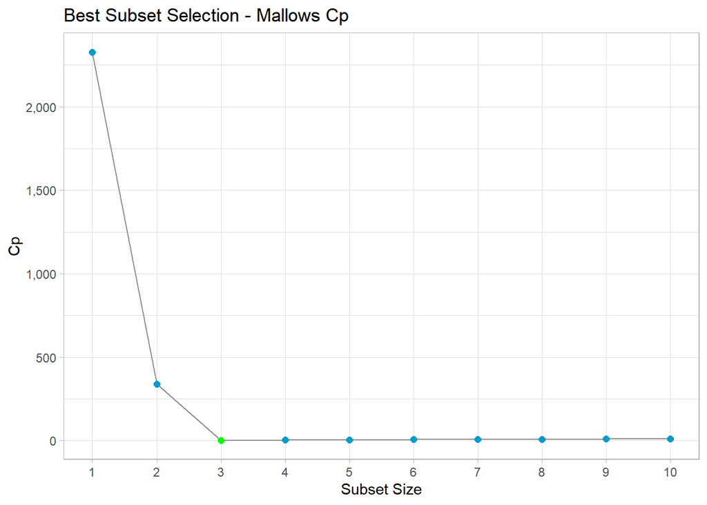

```r
data.frame(cp = model_summary$cp, subset_size = 1:10) %>%
  mutate(min_cp = as.numeric(min(cp) == cp)) %>%
  ggplot(aes(x = subset_size, y = cp)) +
  geom_line(col = "grey55") +
  geom_point(size = 2, aes(col = factor(min_cp))) +
  scale_x_continuous(breaks = seq(1, 10), minor_breaks = NULL) +
  scale_y_continuous(labels = scales::comma_format()) +
  scale_color_manual(values = c("deepskyblue3", "green")) +
  theme(legend.position = "none") +
  labs(title = "Best Subset Selection - Mallows Cp",
       x = "Subset Size",
       y = "Cp")
```

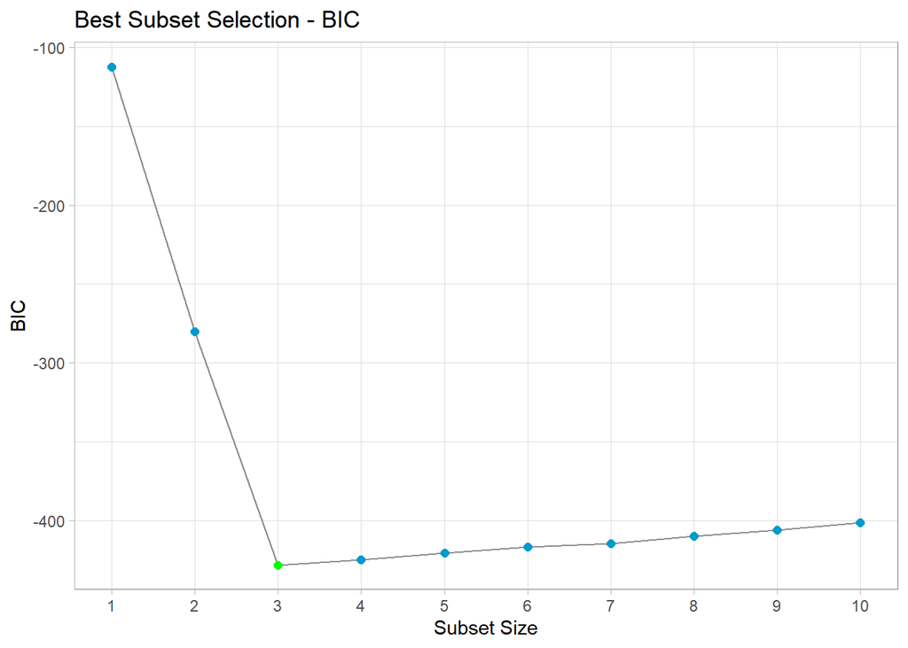

```r
data.frame(bic = model_summary$bic, subset_size = 1:10) %>%
  mutate(min_bic = as.numeric(min(bic) == bic)) %>%
  ggplot(aes(x = subset_size, y = bic)) +
  geom_line(col = "grey55") +
  geom_point(size = 2, aes(col = factor(min_bic))) +
  scale_x_continuous(breaks = seq(1, 10), minor_breaks = NULL) +
  scale_color_manual(values = c("deepskyblue3", "green")) +
  theme(legend.position = "none") +
  labs(title = "Best Subset Selection - BIC",
       x = "Subset Size",
       y = "BIC")
```

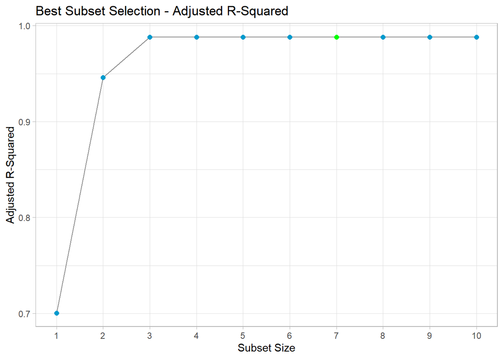

```r
data.frame(adj_r2 = model_summary$adjr2, subset_size = 1:10) %>%
  mutate(max_adj_r2 = as.numeric(max(adj_r2) == adj_r2)) %>%
  ggplot(aes(x = subset_size, y = adj_r2)) +
  geom_line(col = "grey55") +
  geom_point(size = 2, aes(col = factor(max_adj_r2))) +
  scale_x_continuous(breaks = seq(1, 10), minor_breaks = NULL) +
  scale_color_manual(values = c("deepskyblue3", "green")) +
  theme(legend.position = "none") +
  labs(title = "Best Subset Selection - Adjusted R-Squared",
       x = "Subset Size",
       y = "Adjusted R-Squared")
```

```r
model_summary$outmat
```

```
##           1   2   3   4   5   6   7   8   9   10
## 1  ( 1 )  " " "*" " " " " " " " " " " " " " " " "
## 2  ( 1 )  " " "*" " " " " "*" " " " " " " " " " "
## 3  ( 1 )  "*" "*" "*" " " " " " " " " " " " " " "
## 4  ( 1 )  "*" "*" "*" " " " " "*" " " " " " " " "
## 5  ( 1 )  "*" "*" "*" " " " " " " "*" " " "*" " "
## 6  ( 1 )  "*" "*" "*" "*" " " "*" " " "*" " " " "
## 7  ( 1 )  "*" "*" "*" "*" " " "*" " " "*" " " "*"
## 8  ( 1 )  "*" "*" "*" "*" "*" "*" " " "*" " " "*"
## 9  ( 1 )  "*" "*" "*" "*" "*" "*" "*" "*" " " "*"
## 10  ( 1 ) "*" "*" "*" "*" "*" "*" "*" "*" "*" "*"
```

coefficients :

```r
coef(model, id = 3)
```

```
## (Intercept)           1           2           3
##    9.970394   -5.079554    5.908457    3.020436
```

```r
coef(model, id = 7)
```

```
## (Intercept)           1           2           3           4           6
##   9.7931750  -5.1092516   8.2758848   3.0530514  -4.0243410   2.2138377
##           8          10
##  -0.4870719   0.0373538
```

**(d) Other Selection Algorithms** Q: Repeat (c), using forward stepwise selection and also using backwards stepwise selection. How does your answer compare to the results in (c)?

```r
model <- regsubsets(y = Y,
                    x = X_matrix,
                    nvmax = 10,
                    method = "forward")

model_summary <- summary(model)
```

```r
which.min(model_summary$cp)
```

```
## [1] 4
```

```r
which.min(model_summary$bic)
```

```
## [1] 4
```

```r
which.max(model_summary$adjr2)
```

```
## [1] 5
```

```r
coef(model, id = 4)
```

```
##  (Intercept)            1            2            3            5
##  9.970679609 -5.118569011  5.905942599  3.065426465 -0.008184758
```

```r
coef(model, id = 5)
```

```
##  (Intercept)            1            2            3            5            9
##  9.997687418 -4.829782509  5.862875876  2.505181775  0.197180909 -0.004256077
```

```r
which.min(model_summary$cp)
```

```
## [1] 4
```

```r
which.min(model_summary$bic)
```

```
## [1] 4
```

```r
which.max(model_summary$adjr2)
```

```
## [1] 5
```

```r
coef(model, id = 3)
```

```
## (Intercept)           1           2           5
##   9.9457263  -2.2069450   6.0872672   0.5184988
```

```r
coef(model, id = 7)
```

```
##   (Intercept)             1             2             3             5
## 10.0638345725 -4.8552926520  5.6721462089  2.5739803055  0.1723293201
##             6             9            10
##  0.0271268793 -0.0038886359 -0.0007438478
```

**(e) Lasso Selection**

Q: Now fit a lasso model to the simulated data, again using X,X2,…,X10 as predictors. Use cross-validation to select the optimal value of λ. Create plots of the cross-validation error as a function of λ. Report the resulting coefficient estimates, and discuss the results obtained.

```r
model_lasso <- cv.glmnet(y = Y,
                         x = X_matrix,
                         alpha = 1,
                         lambda = 10^seq(1,-2, length = 100),
                         standardize = TRUE,
                         nfolds = 5)
```

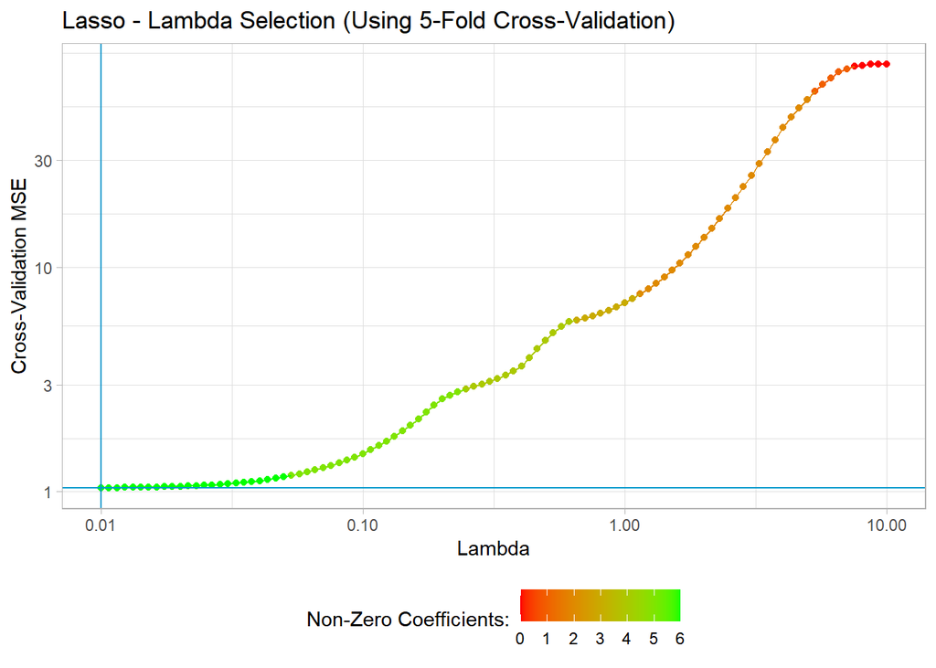

```r
data.frame(lambda = model_lasso$lambda,
           cv_mse = model_lasso$cvm,
           nonzero_coeff = model_lasso$nzero) %>%
  ggplot(aes(x = lambda, y = cv_mse, col = nonzero_coeff)) +
  geom_point() +
  geom_line() +
  geom_vline(xintercept = model_lasso$lambda.min, col = "deepskyblue3") +
  geom_hline(yintercept = min(model_lasso$cvm), col = "deepskyblue3") +
  scale_x_continuous(trans = 'log10') +
  scale_y_continuous(trans = 'log10') +
  theme(legend.position = "bottom") +
  scale_color_gradient(low = "red", high = "green") +
  labs(x = "Lambda",
       y = "Cross-Validation MSE",
       col = "Non-Zero Coefficients:",
       title = "Lasso - Lambda Selection (Using 5-Fold Cross-Validation)")
```

```r
model_lasso_best <- glmnet(y = Y, x = X_matrix, alpha = 1)

predict(model_lasso_best, s = model_lasso$lambda.min, type = "coefficients")
```

```
## 11 x 1 sparse Matrix of class "dgCMatrix"
##                       1
## (Intercept) 10.05129269
## 1           -4.88629024
## 2            5.72519308
## 3            2.86863837
## 4            0.01103157
## 5            0.02355534
## 6            0.00781041
## 7            .
## 8            .
## 9            .
## 10           .
```

**(f) New Example - Best Subset vs Lasso** Q: Now generate a response vector Y according to the model Y=β0+β7X7+ϵ, and perform best subset selection and the lasso. Discuss the results obtained.

```r
Y <- 10 + 5*X^7 + error
```

```r
model <- regsubsets(y = Y,
                    x = X_matrix,
                    nvmax = 10,
                    method = "exhaustive")

model_summary <- summary(model)
```

```r
which.min(model_summary$cp)
```

```
## [1] 1
```

```r
which.min(model_summary$bic)
```

```
## [1] 1
```

```r
which.max(model_summary$adjr2)
```

```
## [1] 6
```

```r
model_summary$outmat
```

```
##           1   2   3   4   5   6   7   8   9   10
## 1  ( 1 )  " " " " " " " " " " " " "*" " " " " " "
## 2  ( 1 )  " " "*" " " " " " " " " "*" " " " " " "
## 3  ( 1 )  " " "*" " " " " " " "*" "*" " " " " " "
## 4  ( 1 )  " " " " " " "*" " " "*" "*" "*" " " " "
## 5  ( 1 )  " " "*" " " "*" " " "*" "*" "*" " " " "
## 6  ( 1 )  " " "*" " " "*" " " "*" "*" "*" " " "*"
## 7  ( 1 )  "*" "*" " " "*" " " "*" "*" "*" " " "*"
## 8  ( 1 )  " " "*" "*" "*" " " "*" "*" "*" "*" "*"
## 9  ( 1 )  "*" "*" "*" "*" "*" "*" "*" "*" " " "*"
## 10  ( 1 ) "*" "*" "*" "*" "*" "*" "*" "*" "*" "*"
```

we have β0^≈10 and β7^≈5

```r
coef(model, id = 1)
```

```
## (Intercept)           7
##    9.893251    4.999704
```

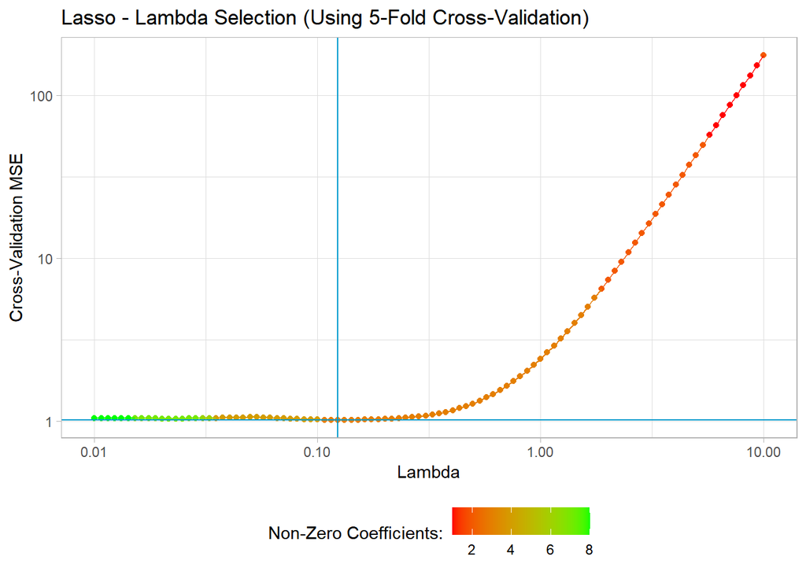

```r
set.seed(2)

model_lasso <- cv.glmnet(y = Y,
                         x = X_matrix,
                         alpha = 1,
                         lambda = 10^seq(1,-2, length = 100),
                         standardize = TRUE,
                         nfolds = 5)

data.frame(lambda = model_lasso$lambda,
           cv_mse = model_lasso$cvm,
           nonzero_coeff = model_lasso$nzero) %>%
  ggplot(aes(x = lambda, y = cv_mse, col = nonzero_coeff)) +
  geom_point() +
  geom_line() +
  geom_vline(xintercept = model_lasso$lambda.min, col = "deepskyblue3") +
  geom_hline(yintercept = min(model_lasso$cvm), col = "deepskyblue3") +
  scale_x_continuous(trans = 'log10') +
    scale_y_continuous(trans = 'log10') +
  theme(legend.position = "bottom") +
  scale_color_gradient(low = "red", high = "green") +
  labs(x = "Lambda",
       y = "Cross-Validation MSE",
       col = "Non-Zero Coefficients:",
       title = "Lasso - Lambda Selection (Using 5-Fold Cross-Validation)")
```

```r
model_lasso_best <- glmnet(y = Y, x = X_matrix, alpha = 1)

predict(model_lasso_best, s = model_lasso$lambda.min, type = "coefficients")
```

```
## 11 x 1 sparse Matrix of class "dgCMatrix"
##                    1
## (Intercept) 10.28679
## 1            .
## 2            .
## 3            .
## 4            .
## 5            .
## 6            .
## 7            4.85396
## 8            .
## 9            .
## 10           .
```

## Problem 9

**(a) train/test Split** Q: Split the data set into a training set and a test set.

```r
set.seed(3)
train_index <- sample(1:nrow(College), round(nrow(College) * 0.7))

train <- College[train_index, ]
nrow(train) / nrow(College)
```

```
## [1] 0.7001287
```

```r
test <- College[-train_index, ]
nrow(test) / nrow(College)
```

```
## [1] 0.2998713
```

**(b) OLS Regression** Q: Fit a linear model using least squares on the training set, and report the test error obtained.

```r
model_linear <- lm(Apps ~ ., data = train)
summary(model_linear)
```

```
##
## Call:
## lm(formula = Apps ~ ., data = train)
##
## Residuals:
##     Min      1Q  Median      3Q     Max
## -3371.9  -437.6   -63.3   350.2  6233.4
##
## Coefficients:
##               Estimate Std. Error t value Pr(>|t|)
## (Intercept) -605.81244  493.25798  -1.228 0.219927
## PrivateYes  -584.35163  164.18527  -3.559 0.000406 ***
## Accept         1.32861    0.06124  21.696  < 2e-16 ***
## Enroll        -0.24166    0.21699  -1.114 0.265908
## Top10perc     52.92817    6.99182   7.570 1.68e-13 ***
## Top25perc    -17.86210    5.44140  -3.283 0.001097 **
## F.Undergrad    0.04199    0.03837   1.094 0.274342
## P.Undergrad    0.04110    0.03435   1.197 0.231996
## Outstate      -0.07531    0.02325  -3.239 0.001274 **
## Room.Board     0.17973    0.05972   3.010 0.002742 **
## Books         -0.09909    0.26773  -0.370 0.711436
## Personal       0.02642    0.07653   0.345 0.730076
## PhD           -9.93047    5.51335  -1.801 0.072249 .
## Terminal      -5.68887    6.08867  -0.934 0.350559
## S.F.Ratio     23.09251   15.20844   1.518 0.129514
## perc.alumni   -6.52534    5.04819  -1.293 0.196713
## Expend         0.12521    0.01797   6.966 9.77e-12 ***
## Grad.Rate     10.65431    3.52288   3.024 0.002614 **
## ---
## Signif. codes:  0 '***' 0.001 '**' 0.01 '*' 0.05 '.' 0.1 ' ' 1
##
## Residual standard error: 1042 on 526 degrees of freedom
## Multiple R-squared:  0.9215, Adjusted R-squared:  0.9189
## F-statistic:   363 on 17 and 526 DF,  p-value: < 2.2e-16
```

```r
ols_pred <- predict(model_linear, test)
(ols_mse <- mean((ols_pred - test$Apps)^2))
```

```
## [1] 1413287
```

**(c) Ridge Regression** Q: Fit a ridge regression model on the training set, with λ chosen by cross-validation. Report the test error obtained.

```r
train_mat <- dummyVars(Apps ~ ., data = train, fullRank = F) %>%
  predict(newdata = train) %>%
  as.matrix()

test_mat <- dummyVars(Apps ~ ., data = test, fullRank = F) %>%
  predict(newdata = test) %>%
  as.matrix()
```

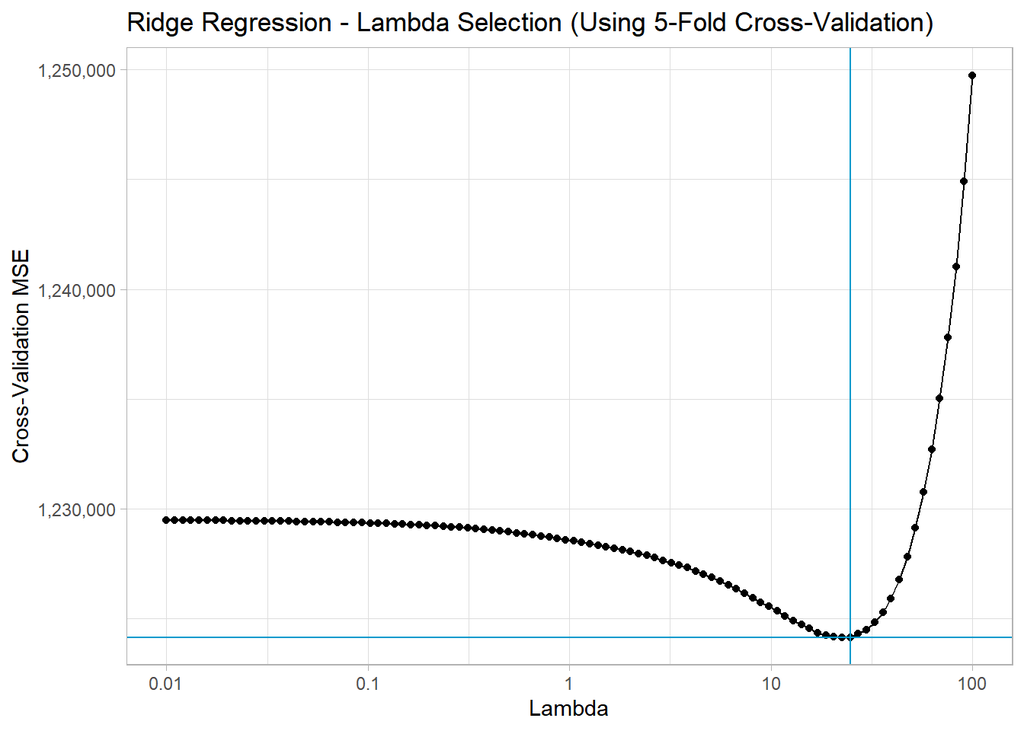

```r
set.seed(3)

model_ridge <- cv.glmnet(y = train$Apps,
                         x = train_mat,
                         alpha = 0,
                         lambda = 10^seq(2,-2, length = 100),
                         standardize = TRUE,
                         nfolds = 5)

data.frame(lambda = model_ridge$lambda,
           cv_mse = model_ridge$cvm) %>%
  ggplot(aes(x = lambda, y = cv_mse)) +
  geom_point() +
  geom_line() +
  geom_vline(xintercept = model_ridge$lambda.min, col = "deepskyblue3") +
  geom_hline(yintercept = min(model_ridge$cvm), col = "deepskyblue3") +
  scale_x_continuous(trans = 'log10', breaks = c(0.01, 0.1, 1, 10, 100), labels = c(0.01, 0.1, 1, 10, 100)) +
  scale_y_continuous(labels = scales::comma_format()) +
  theme(legend.position = "bottom") +
  labs(x = "Lambda",
       y = "Cross-Validation MSE",
       col = "Non-Zero Coefficients:",
       title = "Ridge Regression - Lambda Selection (Using 5-Fold Cross-Validation)")
```

```r
model_ridge_best <- glmnet(y = train$Apps,
                           x = train_mat,
                           alpha = 0,
                           lambda = 10^seq(2,-2, length = 100))

ridge_pred <- predict(model_ridge_best, s = model_ridge$lambda.min, newx = test_mat)
(ridge_mse <- mean((ridge_pred - test$Apps)^2))
```

```
## [1] 1545921
```

**(d) The Lasso**

Q: Fit a lasso model on the training set, with λ chosen by cross-validation. Report the test error obtained, along with the number of non-zero coefficient estimates.

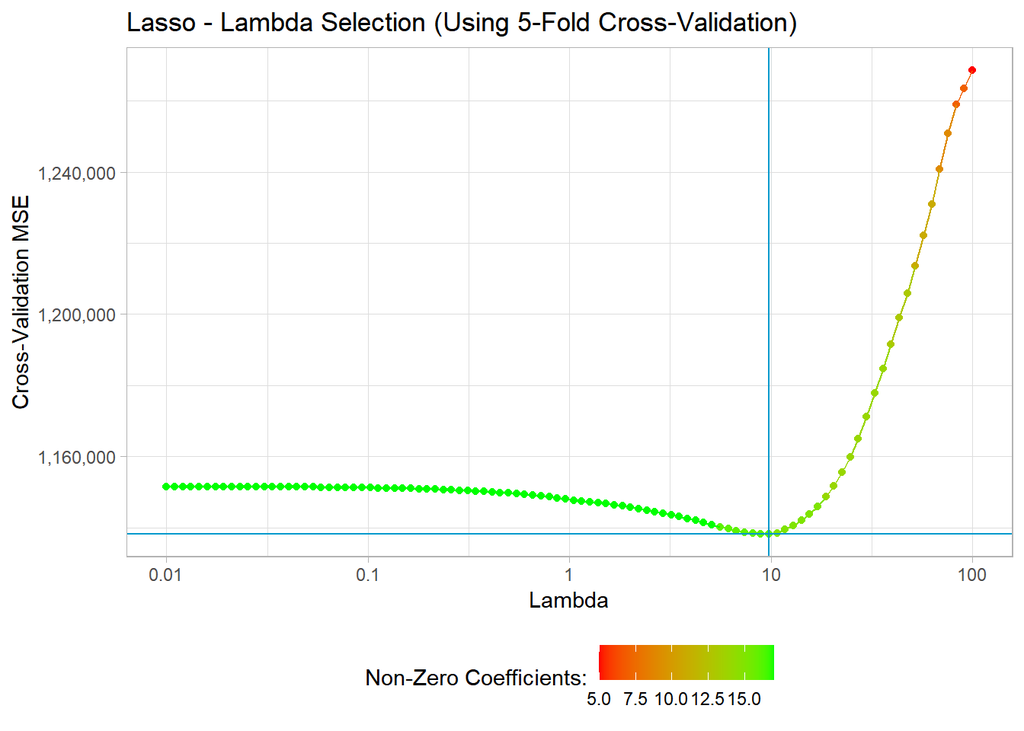

```r
set.seed(4)

model_lasso <- cv.glmnet(y = train$Apps,
                         x = train_mat,
                         alpha = 1,
                         lambda = 10^seq(2, -2, length = 100),
                         standardize = TRUE,
                         nfolds = 5,
                         thresh = 1e-12)

data.frame(lambda = model_lasso$lambda,
           cv_mse = model_lasso$cvm,
           nonzero_coeff = model_lasso$nzero) %>%
  ggplot(aes(x = lambda, y = cv_mse, col = nonzero_coeff)) +
  geom_point() +
  geom_line() +
  geom_vline(xintercept = model_lasso$lambda.min, col = "deepskyblue3") +
  geom_hline(yintercept = min(model_lasso$cvm), col = "deepskyblue3") +
  scale_x_continuous(trans = 'log10', breaks = c(0.01, 0.1, 1, 10, 100), labels = c(0.01, 0.1, 1, 10, 100)) +
  scale_y_continuous(labels = scales::comma_format()) +
  theme(legend.position = "bottom") +
  scale_color_gradient(low = "red", high = "green") +
  labs(x = "Lambda",
       y = "Cross-Validation MSE",
       col = "Non-Zero Coefficients:",
       title = "Lasso - Lambda Selection (Using 5-Fold Cross-Validation)")
```

```r
model_lasso_best <- glmnet(y = train$Apps,
                           x = train_mat,
                           alpha = 1,
                           lambda = 10^seq(2,-5, length = 100))

lasso_pred <- predict(model_lasso_best, s = model_lasso$lambda.min, newx = test_mat)
(lasso_mse <- mean((lasso_pred - test$Apps)^2))
```

```
## [1] 1444668
```

```r
lasso_coef <- predict(model_lasso_best, type = "coefficients", s = model_lasso$lambda.min)

round(lasso_coef, 3)
```

```
## 19 x 1 sparse Matrix of class "dgCMatrix"
##                     1
## (Intercept) -1302.682
## Private.No    568.744
## Private.Yes     .
## Accept          1.281
## Enroll          .
## Top10perc      46.089
## Top25perc     -12.664
## F.Undergrad     0.018
## P.Undergrad     0.035
## Outstate       -0.063
## Room.Board      0.164
## Books          -0.004
## Personal        0.010
## PhD            -8.092
## Terminal       -5.653
## S.F.Ratio      18.699
## perc.alumni    -7.071
## Expend          0.120
## Grad.Rate       9.274
```

**(e) Principal Components Regression** Q: Fit a PCR model on the training set, with M chosen by cross-validation. Report the test error obtained, along with the value of M selected by cross-validation.

```r
set.seed(5)

model_pcr <- pcr(Apps ~ .,
                 data = train,
                 scale = T,
                 validation = "CV")

model_pcr_mse <- MSEP(model_pcr, estimate = "CV")$val %>%
  reshape2::melt() %>%
  mutate(M = 0:(nrow(.)-1)) %>%
  select(M, value) %>%
  rename(CV_MSE = value)

model_pcr_mse
```

```
##     M   CV_MSE
## 1   0 13409401
## 2   1 13221496
## 3   2  3031993
## 4   3  3073801
## 5   4  2444471
## 6   5  2078195
## 7   6  1836587
## 8   7  1671864
## 9   8  1593721
## 10  9  1607070
## 11 10  1598481
## 12 11  1608062
## 13 12  1587359
## 14 13  1600032
## 15 14  1598151
## 16 15  1613936
## 17 16  1203941
## 18 17  1207079
```

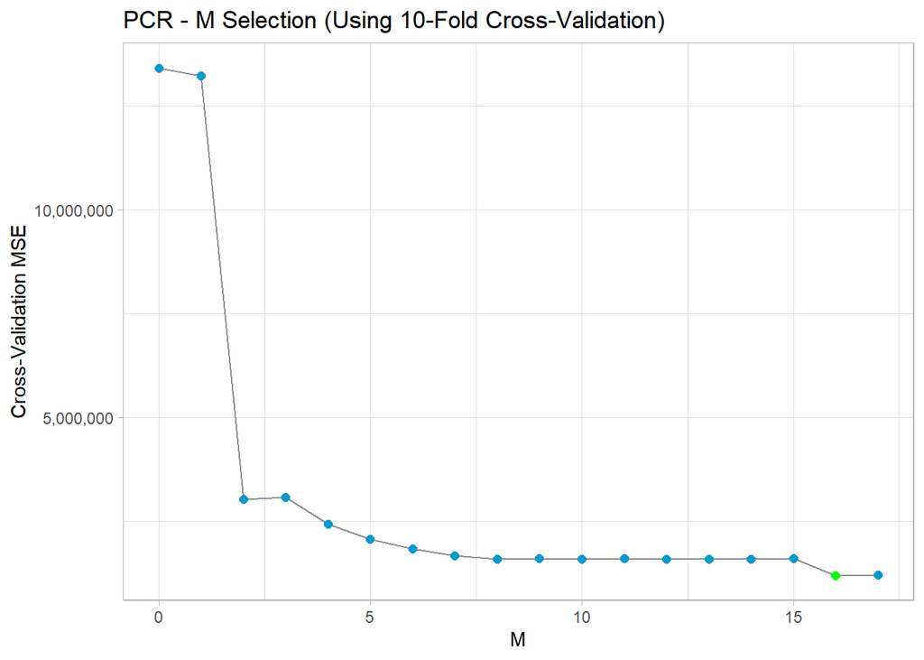

```r
model_pcr_mse %>%
  mutate(min_CV_MSE = as.numeric(min(CV_MSE) == CV_MSE)) %>%
  ggplot(aes(x = M, y = CV_MSE)) +
  geom_line(col = "grey55") +
  geom_point(size = 2, aes(col = factor(min_CV_MSE))) +
  scale_y_continuous(labels = scales::comma_format()) +
  scale_color_manual(values = c("deepskyblue3", "green")) +
  theme(legend.position = "none") +
  labs(x = "M",
       y = "Cross-Validation MSE",
       col = "Non-Zero Coefficients:",
       title = "PCR - M Selection (Using 10-Fold Cross-Validation)")
```

```r
pcr_pred <- predict(model_pcr, test, ncomp = 17)
(pcr_mse <- mean((pcr_pred - test$Apps)^2))
```

```
## [1] 1413287
```

**(f) Partial Least Squares Regression** Q: Fit a PLS model on the training set, with M chosen by crossvalidation. Report the test error obtained, along with the value of M selected by cross-validation.

```r
set.seed(6)

model_pls <- plsr(Apps ~ .,
                  data = train,
                  scale = T,
                  validation = "CV")

model_pls_mse <- MSEP(model_pls, estimate = "CV")$val %>%
  reshape2::melt() %>%
  mutate(M = 0:(nrow(.)-1)) %>%
  select(M, value) %>%
  rename(CV_MSE = value)

model_pls_mse
```

```
##     M   CV_MSE
## 1   0 13409401
## 2   1  2550956
## 3   2  1823854
## 4   3  1502580
## 5   4  1443224
## 6   5  1373482
## 7   6  1269080
## 8   7  1236585
## 9   8  1229345
## 10  9  1229525
## 11 10  1232714
## 12 11  1232950
## 13 12  1234544
## 14 13  1238947
## 15 14  1240060
## 16 15  1239458
## 17 16  1239412
## 18 17  1239557
```

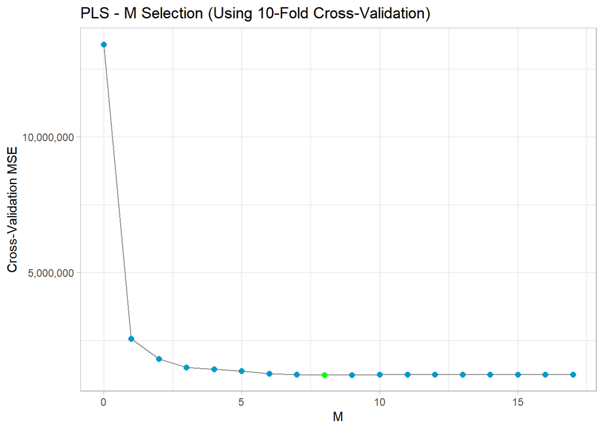

```r
model_pls_mse %>%
  mutate(min_CV_MSE = as.numeric(min(CV_MSE) == CV_MSE)) %>%
  ggplot(aes(x = M, y = CV_MSE)) +
  geom_line(col = "grey55") +
  geom_point(size = 2, aes(col = factor(min_CV_MSE))) +
  scale_y_continuous(labels = scales::comma_format()) +
  scale_color_manual(values = c("deepskyblue3", "green")) +
  theme(legend.position = "none") +
  labs(x = "M",
       y = "Cross-Validation MSE",
       title = "PLS - M Selection (Using 10-Fold Cross-Validation)")
```

```r
pls_pred <- predict(model_pls, test, ncomp = 12)
(pls_mse <- mean((pls_pred - test$Apps)^2))
```

```
## [1] 1428935
```

**(g) Performance Comparison** Q: Comment on the results obtained. How accurately can we predict the number of college applications received? Is there much difference among the test errors resulting from these five approaches?

```r
# R2 = 1 - (SS_res / SS_tot)^2

SS_tot <- sum((test$Apps - mean(test$Apps))^2)

data.frame(method = c("OLS", "Ridge", "Lasso", "PCR", "PLS"),
           test_MSE = c(ols_mse, ridge_mse, lasso_mse, pcr_mse, pls_mse),
           test_R2 = c(1 - sum((test$Apps - ols_pred)^2) / SS_tot,
                       1 - sum((test$Apps - ridge_pred)^2) / SS_tot,
                       1 - sum((test$Apps - lasso_pred)^2) / SS_tot,
                       1 - sum((test$Apps - pcr_pred)^2) / SS_tot,
                       1 - sum((test$Apps - pls_pred)^2) / SS_tot)) %>%
  arrange(test_MSE)
```

```
##   method test_MSE   test_R2
## 1    OLS  1413287 0.9241061
## 2    PCR  1413287 0.9241061
## 3    PLS  1428935 0.9232658
## 4  Lasso  1444668 0.9224210
## 5  Ridge  1545921 0.9169836
```

##Problem 10

**(a) Generate Data** Q: Generate a data set with p = 20 features, n = 1,000 observations, and an associated quantitative response vector generated according to the model

Y=Xβ+ϵ where β has some elements that are exactly equal to zero.

```r
set.seed(1)
p <- 20
n <- 1000

X <- matrix(data = rnorm(n * p, mean = 0, sd = 1), nrow = n, ncol = p)

B <- rnorm(p, mean = 1, sd = 2)
B[2] <- 0
B[9] <- 0
B[14] <- 0
B[17] <- 0

eps <- rnorm(p, mean = 0, sd = 3)

Y = X %*% B + eps
```

```r
df <- cbind(Y, as.data.frame(X))
names(df) <- c("Y", paste0("X", 1:20))
glimpse(df)
```

```
## Rows: 1,000
## Columns: 21
## $ Y   <dbl> -7.5791363, 9.2157068, 8.2360422, 3.7628364, -6.4013460, 5.5314182~
## $ X1  <dbl> -0.62645381, 0.18364332, -0.83562861, 1.59528080, 0.32950777, -0.8~
## $ X2  <dbl> 1.13496509, 1.11193185, -0.87077763, 0.21073159, 0.06939565, -1.66~
## $ X3  <dbl> -0.88614959, -1.92225490, 1.61970074, 0.51926990, -0.05584993, 0.6~
## $ X4  <dbl> 0.73911492, 0.38660873, 1.29639717, -0.80355836, -1.60262567, 0.93~
## $ X5  <dbl> -1.13463018, 0.76455710, 0.57071014, -1.35169393, -2.02988547, 0.5~
## $ X6  <dbl> -1.5163733, 0.6291412, -1.6781940, 1.1797811, 1.1176545, -1.237735~
## $ X7  <dbl> -0.61882708, -1.10942196, -2.17033523, -0.03130307, -0.26039848, 0~
## $ X8  <dbl> -1.32541772, 0.95197972, 0.86000439, 1.06079031, -0.35058396, -0.1~
## $ X9  <dbl> 0.26370340, -0.82945185, -1.46163477, 1.68399018, -1.54432429, -0.~
## $ X10 <dbl> -1.21712008, -0.94622927, 0.09140980, 0.70135127, 0.67342236, 1.26~
## $ X11 <dbl> -0.80433160, -1.05652565, -1.03539578, -1.18556035, -0.50043951, -~
## $ X12 <dbl> -1.411521883, 1.083869657, 1.170222351, 0.294754540, -0.554427663,~
## $ X13 <dbl> -0.93910663, 1.39366493, 1.62581486, 0.40900106, -0.09255856, 0.20~
## $ X14 <dbl> 0.2264537, -0.8185942, -0.8471526, -1.9843326, -0.8127788, 1.46167~
## $ X15 <dbl> 0.5232667, 0.9935537, 0.2737370, -0.6949193, -0.7180502, -0.101989~
## $ X16 <dbl> -0.21390898, -0.10672328, -0.46458931, -0.68427247, -0.79080075, -~
## $ X17 <dbl> 0.85763410, -1.62539515, -0.23427831, -1.03265445, -1.14114122, -1~
## $ X18 <dbl> 1.0496171412, 0.2903237344, 1.2421262227, -0.6850857039, -0.667768~
## $ X19 <dbl> 0.95140989, 0.45709866, -0.35869346, -1.04586136, 0.30753453, 1.99~
## $ X20 <dbl> -2.07771241, -0.45446091, -0.16555991, 0.89765209, -0.02948916, 1.~
```

**(b) train/test Split** Q: Split your data set into a training set containing 100 observations and a test set containing 900 observations.

```r
set.seed(2)
train_index <- sample(1:1000, 100)

train <- df[train_index, ]
nrow(train) / nrow(df)
```

```
## [1] 0.1
```

```r
test <- df[-train_index, ]
nrow(test) / nrow(df)
```

```
## [1] 0.9
```

**(c) train MSE Selection** Q: Perform best subset selection on the training set, and plot the training set MSE associated with the best model of each size.

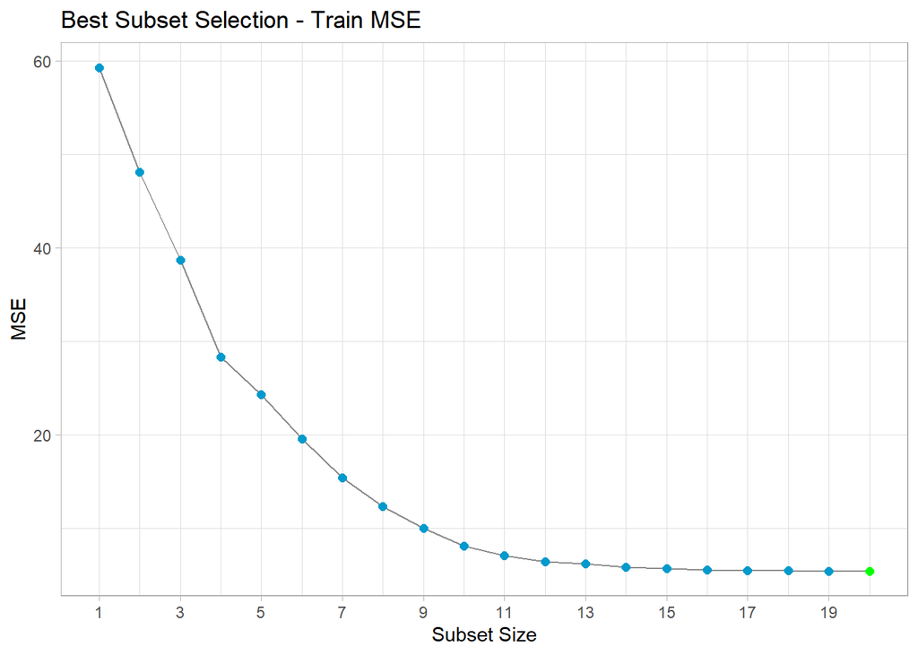

```r
model <- regsubsets(Y ~ .,
                    data = train,
                    nvmax = 20,
                    method = "exhaustive")

model_summary <- summary(model)

data.frame(MSE = model_summary$rss / nrow(train), subset_size = 1:20) %>%
  mutate(min_MSE = as.numeric(min(MSE) == MSE)) %>%
  ggplot(aes(x = subset_size, y = MSE)) +
  geom_line(col = "grey55") +
  geom_point(size = 2, aes(col = factor(min_MSE))) +
  scale_x_continuous(breaks = seq(1, 20, 2)) +
  scale_y_continuous(labels = scales::comma_format()) +
  scale_color_manual(values = c("deepskyblue3", "green")) +
  theme(legend.position = "none") +
  labs(title = "Best Subset Selection - Train MSE",
       x = "Subset Size",
       y = "MSE")
```

**(d) test MSE Selection** Q: Plot the test set MSE associated with the best model of each size.

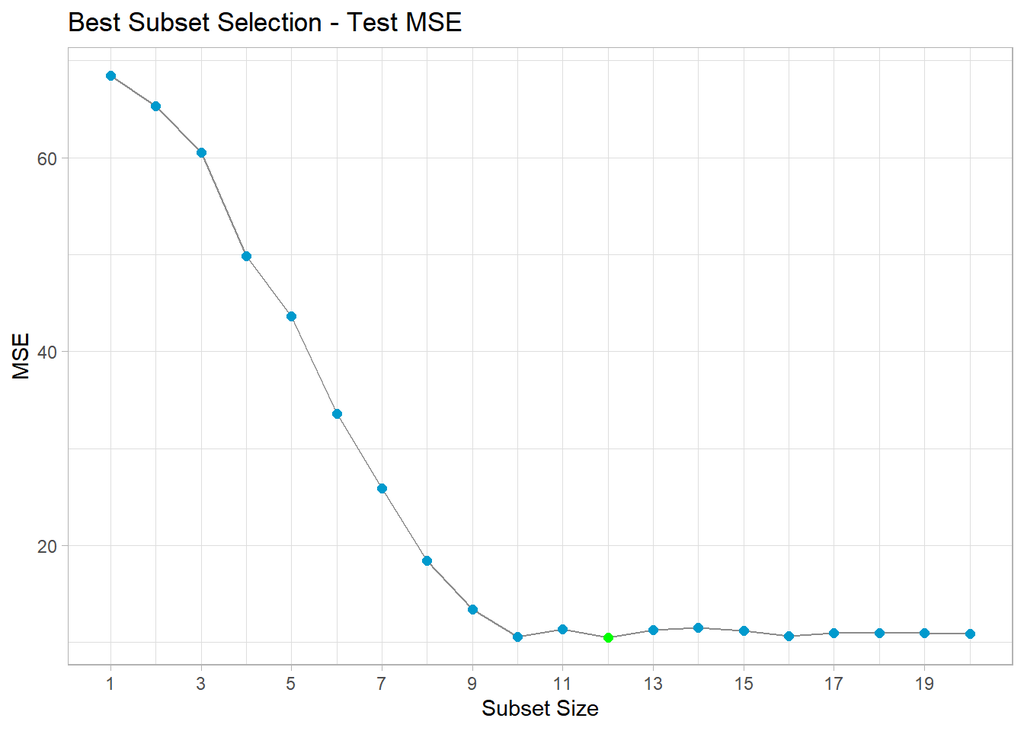

```r
X_test <- cbind("(Intercept)" = 1, as.matrix(test[ ,-1])) # remove y
MSE_test <- c()

for (i in 1:ncol(model_summary$outmat)) {
  model_coef <- coef(model, id = i)
  pred <- X_test[, colnames(X_test) %in% names(model_coef)] %*% model_coef
  MSE_test[i] <- mean((test$Y - pred)^2)
}

data.frame(MSE = MSE_test, subset_size = 1:20) %>%
  mutate(min_MSE = as.numeric(min(MSE) == MSE)) %>%
  ggplot(aes(x = subset_size, y = MSE)) +
  geom_line(col = "grey55") +
  geom_point(size = 2, aes(col = factor(min_MSE))) +
  scale_x_continuous(breaks = seq(1, 20, 2)) +
  scale_y_continuous(labels = scales::comma_format()) +
  scale_color_manual(values = c("deepskyblue3", "green")) +
  theme(legend.position = "none") +
  labs(title = "Best Subset Selection - Test MSE",
       x = "Subset Size",
       y = "MSE")
```

```r
params <- data.frame(parameter = colnames(model_summary$which), actual = c(0, B)) %>%
  left_join(data.frame(parameter = names(coef(model, id = 14)), estimated = coef(model, id = 14)), by = "parameter") %>%
  mutate(estimated = case_when(is.na(estimated) ~ 0, TRUE ~ estimated))

params
```

```
##      parameter     actual  estimated
## 1  (Intercept)  0.0000000  0.5179533
## 2           X1  1.4706970  1.4286795
## 3           X2  0.0000000  0.0000000
## 4           X3 -0.2843738 -0.8515489
## 5           X4 -2.8696170 -3.2123195
## 6           X5  3.0773913  2.5763959
## 7           X6  0.4328998  0.0000000
## 8           X7 -1.8194582 -2.0273867
## 9           X8  2.4463609  2.6091941
## 10          X9  0.0000000  0.0000000
## 11         X10  2.4609806  1.8494671
## 12         X11  2.7583068  3.1468649
## 13         X12  2.1091128  1.6800076
## 14         X13  0.4308379  0.0000000
## 15         X14  0.0000000  0.0000000
## 16         X15 -0.4309777  0.0000000
## 17         X16  0.4589441  0.6291659
## 18         X17  0.0000000 -0.6647102
## 19         X18  4.3396136  4.1346244
## 20         X19  2.7845185  2.2327768
## 21         X20 -1.0309778 -0.9738666
```

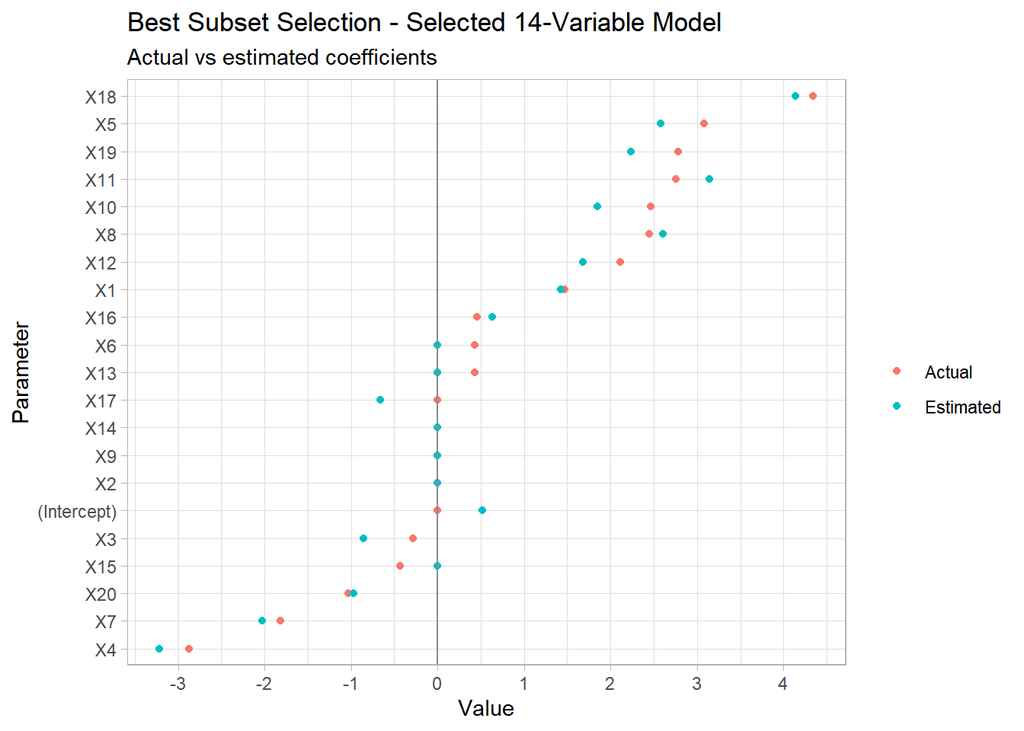

```r
params_plot <- params %>%
  arrange(actual)

params_plot$parameter <- factor(params_plot$parameter, ordered = TRUE, levels = params_plot$parameter)

params_plot %>%
  gather("key", "value", -parameter) %>%
  ggplot(aes(x = value, y = parameter, col = factor(key))) +
  geom_point() +
  geom_vline(xintercept = 0, col = "grey55") +
  scale_x_continuous(breaks = seq(-6, 6)) +
  scale_color_discrete(labels = c("Actual", "Estimated")) +
  labs(x = "Value",
       y = "Parameter",
       col = "",
       title = "Best Subset Selection - Selected 14-Variable Model",
       subtitle = "Actual vs estimated coefficients")
```

```r
selected_model <- lm(Y ~ ., data = train[ ,c("Y", names(coef(model, id = 14)[-1]))])

1 - sum((train$Y - predict(selected_model))^2) / sum((train$Y - mean(train$Y))^2)
```

```
## [1] 0.9267633
```

**(g) Actual vs Estimated Parameter ‘Distance’**

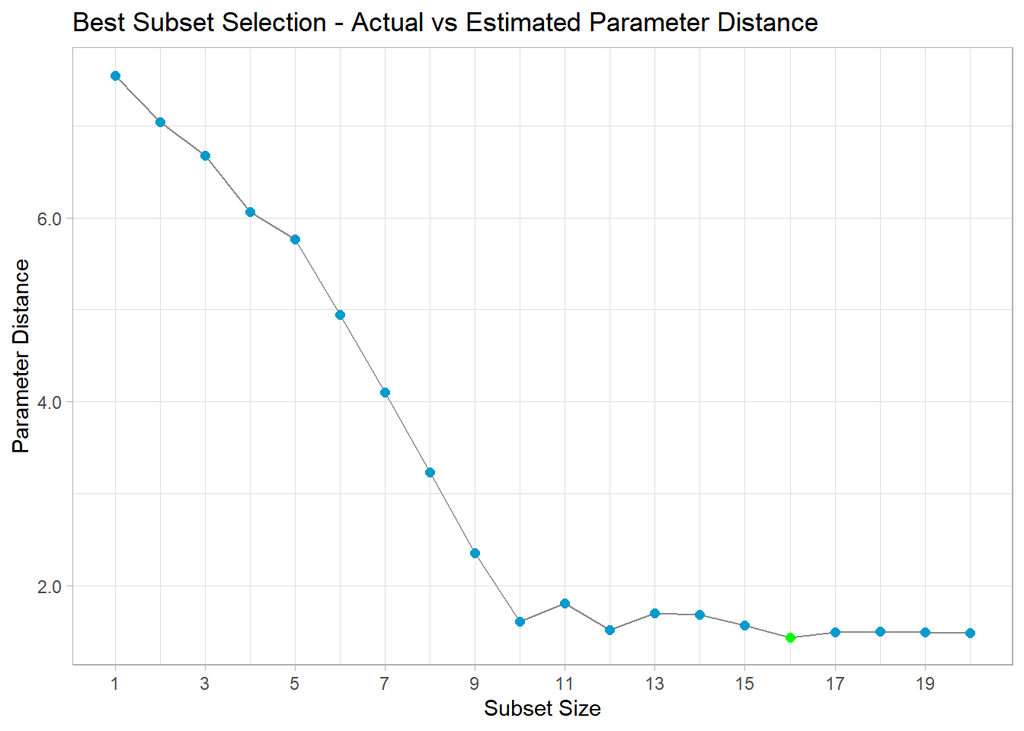

```r
param_dist <- c()

for (j in 1:20) {
  params <- data.frame(parameter = colnames(model_summary$which)[-1], actual = B) %>%
    left_join(data.frame(parameter = names(coef(model, id = j)), estimated = coef(model, id = j)), by = "parameter") %>%
    mutate(estimated = case_when(is.na(estimated) ~ 0, TRUE ~ estimated))

  param_dist[j] <- sqrt(sum((params$actual - params$estimated)^2))
}


data.frame(dist = param_dist, subset_size = 1:20) %>%
  mutate(min_dist = as.numeric(min(dist) == dist)) %>%
  ggplot(aes(x = subset_size, y = dist)) +
  geom_line(col = "grey55") +
  geom_point(size = 2, aes(col = factor(min_dist))) +
  scale_x_continuous(breaks = seq(1, 20, 2)) +
  scale_y_continuous(labels = scales::comma_format()) +
  scale_color_manual(values = c("deepskyblue3", "green")) +
  theme(legend.position = "none") +
  labs(title = "Best Subset Selection - Actual vs Estimated Parameter Distance",
       x = "Subset Size",
       y = "Parameter Distance")
```

## Problem 11

**(a) Various Approaches** Q: Try out some of the regression methods explored in this chapter, such as best subset selection, the lasso, ridge regression, and PCR. Present and discuss results for the approaches that you consider.

```r
ctrl <- trainControl(method = "repeatedcv", number = 10, repeats = 10 , summaryFunction = custom_regression_metrics)
```

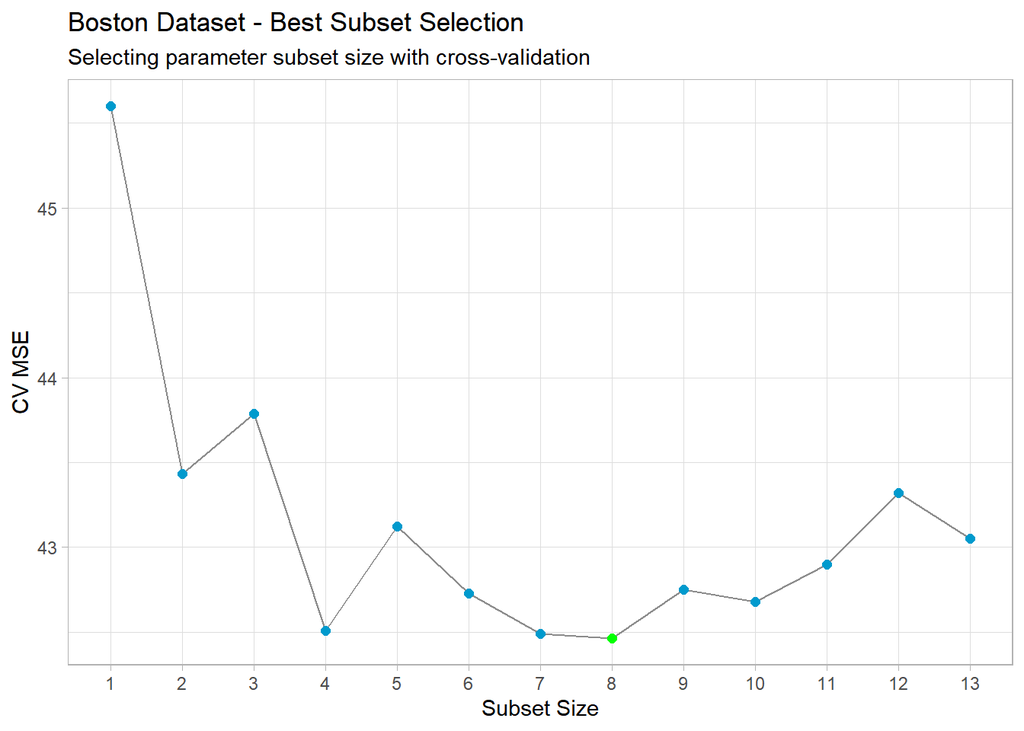

```r
# best models per subset size:
model <- regsubsets(crim ~ .,
                    data = Boston,
                    nvmax = ncol(Boston) - 1,
                    method = "exhaustive")




# cross-validating to compare MSE:

CV_MSE <- c()

set.seed(10101)

for (i in 1:(ncol(Boston)-1)) {
  Boston_temp <- Boston[ ,c("crim", names(coef(model, id = i)[-1]))]
  model_temp <- train(crim ~ .,
                      data = Boston_temp,
                      method = "lm",
                      trControl = ctrl)
  CV_MSE[i] <- model_temp$results$MSE
}

data.frame(CV_MSE = CV_MSE, subset_size = 1:(ncol(Boston)-1)) %>%
  mutate(min_CV_MSE = as.numeric(min(CV_MSE) == CV_MSE)) %>%
  ggplot(aes(x = subset_size, y = CV_MSE)) +
  geom_line(col = "grey55") +
  geom_point(size = 2, aes(col = factor(min_CV_MSE))) +
  scale_x_continuous(breaks = seq(1, ncol(Boston)-1), minor_breaks = NULL) +
  scale_color_manual(values = c("deepskyblue3", "green")) +
  theme(legend.position = "none") +
  labs(title = "Boston Dataset - Best Subset Selection",
       subtitle = "Selecting parameter subset size with cross-validation",
       x = "Subset Size",
       y = "CV MSE")
```

```r
min(CV_MSE)
```

```
## [1] 42.46049
```

**Lasso Regression:**

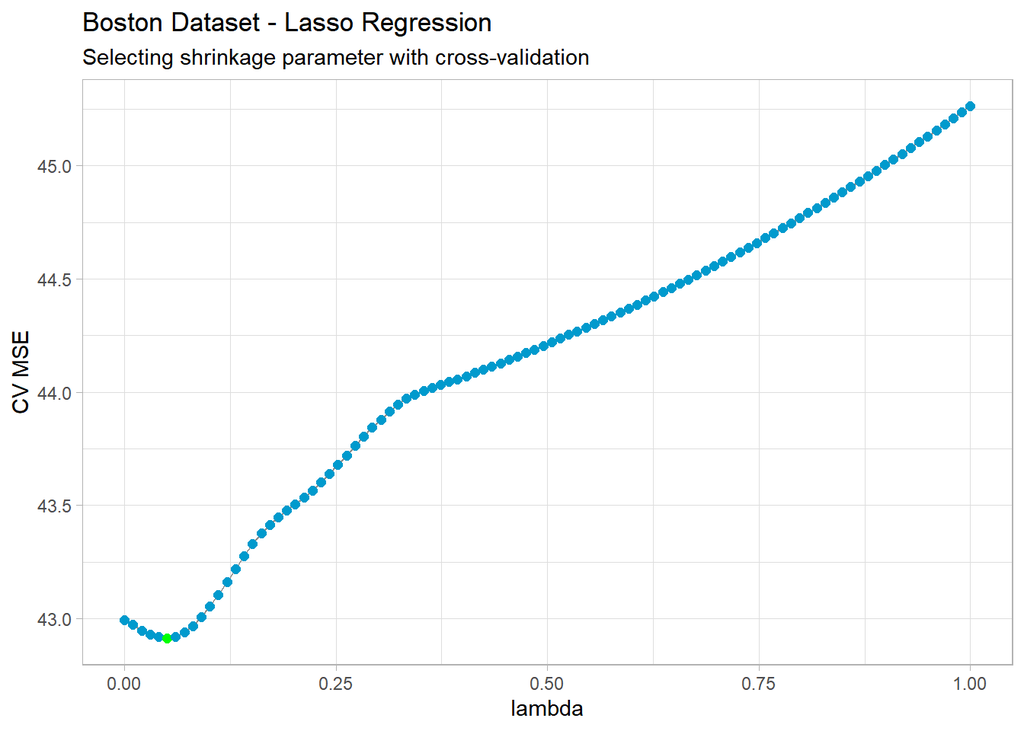

```r
set.seed(159)

model_lasso <- train(crim ~ .,
                     data = Boston,
                     method = "glmnet",
                     preProcess = c("center", "scale"),
                     metric = "MSE",
                     maximize = F,
                     trControl = ctrl,
                     tuneGrid = expand.grid(alpha = 1,
                                            lambda = seq(0, 1, length = 100)))



model_lasso$results %>%
  rename(CV_MSE = MSE) %>%
  mutate(min_CV_MSE = as.numeric(lambda == model_lasso$bestTune$lambda)) %>%
  ggplot(aes(x = lambda, y = CV_MSE)) +
  geom_line(col = "grey55") +
  geom_point(size = 2, aes(col = factor(min_CV_MSE))) +
  scale_color_manual(values = c("deepskyblue3", "green")) +
  theme(legend.position = "none") +
  labs(title = "Boston Dataset - Lasso Regression",
       subtitle = "Selecting shrinkage parameter with cross-validation",
       y = "CV MSE")
```

```r
min(model_lasso$results$MSE)
```

```
## [1] 42.91081
```

**Ridge Regression:**

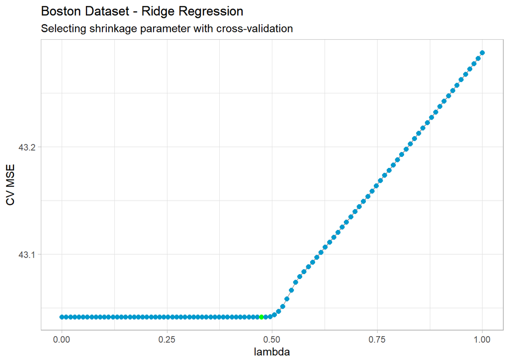

```r
set.seed(159)

model_ridge <- train(crim ~ .,
                     data = Boston,
                     method = "glmnet",
                     preProcess = c("center", "scale"),
                     metric = "MSE",
                     maximize = F,
                     trControl = ctrl,
                     tuneGrid = expand.grid(alpha = 0,
                                            lambda = seq(0, 1, length = 100)))


model_ridge$results %>%
  rename(CV_MSE = MSE) %>%
  mutate(min_CV_MSE = as.numeric(lambda == model_ridge$bestTune$lambda)) %>%
  ggplot(aes(x = lambda, y = CV_MSE)) +
  geom_line(col = "grey55") +
  geom_point(size = 2, aes(col = factor(min_CV_MSE))) +
  scale_color_manual(values = c("deepskyblue3", "green")) +
  theme(legend.position = "none") +
  labs(title = "Boston Dataset - Ridge Regression",
       subtitle = "Selecting shrinkage parameter with cross-validation",
       y = "CV MSE")
```

```r
min(model_ridge$results$MSE)
```

```
## [1] 43.04141
```

**Principal Components Regression:**

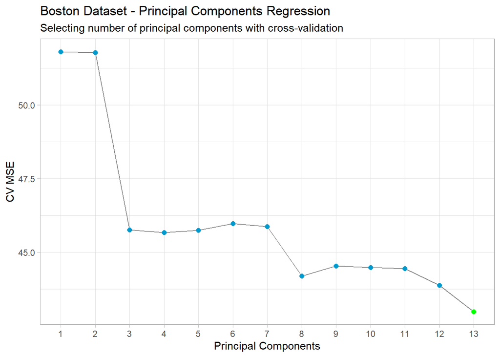

```r
set.seed(339)

model_pcr <- train(crim ~ .,
                   data = Boston,
                   method = "pcr",
                   preProcess = c("center", "scale"),
                   metric = "MSE",
                   maximize = F,
                   trControl = ctrl,
                   tuneGrid = expand.grid(ncomp = 1:(ncol(Boston)-1)))


model_pcr$results %>%
  rename(CV_MSE = MSE) %>%
  mutate(min_CV_MSE = as.numeric(ncomp == model_pcr$bestTune$ncomp)) %>%
  ggplot(aes(x = ncomp, y = CV_MSE)) +
  geom_line(col = "grey55") +
  geom_point(size = 2, aes(col = factor(min_CV_MSE))) +
  scale_x_continuous(breaks = seq(1, ncol(Boston)-1), minor_breaks = NULL) +
  scale_color_manual(values = c("deepskyblue3", "green")) +
  theme(legend.position = "none") +
  labs(title = "Boston Dataset - Principal Components Regression",
       subtitle = "Selecting number of principal components with cross-validation",
       x = "Principal Components",
       y = "CV MSE")
```

```r
min(model_pcr$results$MSE)
```

```
## [1] 42.97377
```

**Partial Least Squares:**

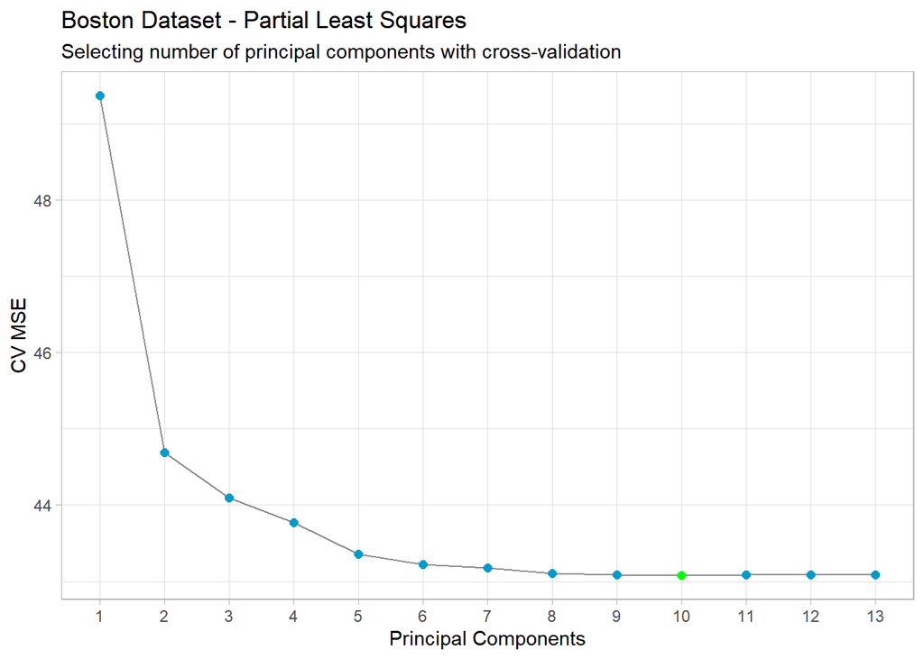

```r
set.seed(840)

model_pls <- train(crim ~ .,
                   data = Boston,
                   method = "pls",
                   preProcess = c("center", "scale"),
                   metric = "MSE",
                   maximize = F,
                   trControl = ctrl,
                   tuneGrid = expand.grid(ncomp = 1:(ncol(Boston)-1)))


model_pls$results %>%
  rename(CV_MSE = MSE) %>%
  mutate(min_CV_MSE = as.numeric(ncomp == model_pls$bestTune$ncomp)) %>%
  ggplot(aes(x = ncomp, y = CV_MSE)) +
  geom_line(col = "grey55") +
  geom_point(size = 2, aes(col = factor(min_CV_MSE))) +
  scale_x_continuous(breaks = seq(1, ncol(Boston)-1), minor_breaks = NULL) +
  scale_color_manual(values = c("deepskyblue3", "green")) +
  theme(legend.position = "none") +
  labs(title = "Boston Dataset - Partial Least Squares",
       subtitle = "Selecting number of principal components with cross-validation",
       x = "Principal Components",
       y = "CV MSE")
```

```r
min(model_pls$results$MSE)
```

```
## [1] 43.07288
```

**(b) Proposed Model** Q: Propose a model (or set of models) that seem to perform well on this data set, and justify your answer. Make sure that you are evaluating model performance using validation set error, crossvalidation, or some other reasonable alternative, as opposed to using training error.

```r
Boston$medv_sq <- Boston$medv^2
Boston$medv_cub <- Boston$medv^3

Boston$rad_cat <- ifelse(Boston$rad > 20, 1, 0)
Boston$rad <- NULL
Boston$tax <- NULL

glimpse(Boston)
```

```
## Rows: 506
## Columns: 15
## $ crim     <dbl> 0.00632, 0.02731, 0.02729, 0.03237, 0.06905, 0.02985, 0.08829~
## $ zn       <dbl> 18.0, 0.0, 0.0, 0.0, 0.0, 0.0, 12.5, 12.5, 12.5, 12.5, 12.5, ~
## $ indus    <dbl> 2.31, 7.07, 7.07, 2.18, 2.18, 2.18, 7.87, 7.87, 7.87, 7.87, 7~
## $ chas     <int> 0, 0, 0, 0, 0, 0, 0, 0, 0, 0, 0, 0, 0, 0, 0, 0, 0, 0, 0, 0, 0~
## $ nox      <dbl> 0.538, 0.469, 0.469, 0.458, 0.458, 0.458, 0.524, 0.524, 0.524~
## $ rm       <dbl> 6.575, 6.421, 7.185, 6.998, 7.147, 6.430, 6.012, 6.172, 5.631~
## $ age      <dbl> 65.2, 78.9, 61.1, 45.8, 54.2, 58.7, 66.6, 96.1, 100.0, 85.9, ~
## $ dis      <dbl> 4.0900, 4.9671, 4.9671, 6.0622, 6.0622, 6.0622, 5.5605, 5.950~
## $ ptratio  <dbl> 15.3, 17.8, 17.8, 18.7, 18.7, 18.7, 15.2, 15.2, 15.2, 15.2, 1~
## $ black    <dbl> 396.90, 396.90, 392.83, 394.63, 396.90, 394.12, 395.60, 396.9~
## $ lstat    <dbl> 4.98, 9.14, 4.03, 2.94, 5.33, 5.21, 12.43, 19.15, 29.93, 17.1~
## $ medv     <dbl> 24.0, 21.6, 34.7, 33.4, 36.2, 28.7, 22.9, 27.1, 16.5, 18.9, 1~
## $ medv_sq  <dbl> 576.00, 466.56, 1204.09, 1115.56, 1310.44, 823.69, 524.41, 73~
## $ medv_cub <dbl> 13824.000, 10077.696, 41781.923, 37259.704, 47437.928, 23639.~
## $ rad_cat  <dbl> 0, 0, 0, 0, 0, 0, 0, 0, 0, 0, 0, 0, 0, 0, 0, 0, 0, 0, 0, 0, 0~
```

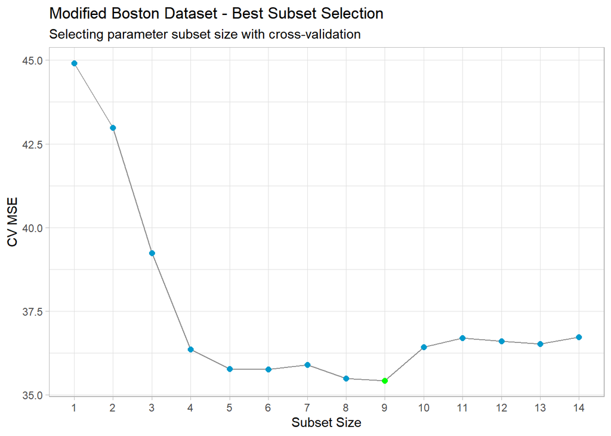

```r
# best models per subset size:
model <- regsubsets(crim ~ .,
                    data = Boston,
                    nvmax = ncol(Boston) - 1,
                    method = "exhaustive")


# cross-validating to compare MSE:
CV_MSE <- c()

set.seed(20202)

for (i in 1:(ncol(Boston)-1)) {
  Boston_temp <- Boston[ ,c("crim", names(coef(model, id = i)[-1]))]
  model_temp <- train(crim ~ .,
                      data = Boston_temp,
                      method = "lm",
                      trControl = ctrl)
  CV_MSE[i] <- model_temp$results$MSE
}

data.frame(CV_MSE = CV_MSE, subset_size = 1:(ncol(Boston)-1)) %>%
  mutate(min_CV_MSE = as.numeric(min(CV_MSE) == CV_MSE)) %>%
  ggplot(aes(x = subset_size, y = CV_MSE)) +
  geom_line(col = "grey55") +
  geom_point(size = 2, aes(col = factor(min_CV_MSE))) +
  scale_x_continuous(breaks = seq(1, ncol(Boston)-1), minor_breaks = NULL) +
  scale_color_manual(values = c("deepskyblue3", "green")) +
  theme(legend.position = "none") +
  labs(title = "Modified Boston Dataset - Best Subset Selection",
       subtitle = "Selecting parameter subset size with cross-validation",
       x = "Subset Size",
       y = "CV MSE")
```

**(c) Selected Model** Q: Does your chosen model involve all of the features in the data set? Why or why not?

```r
coef(model, id = 7)
```

```
##   (Intercept)           nox           dis       ptratio          medv
##  52.291186700 -11.960713097  -0.468287570  -0.328043396  -3.885786605
##       medv_sq      medv_cub       rad_cat
##   0.123927558  -0.001246049   9.187000141
```

```r
coef(model, id = 4)
```

```
##  (Intercept)         medv      medv_sq     medv_cub      rad_cat
## 38.178959648 -4.035693216  0.132937552 -0.001358685  8.101325067
```